# ⚽⚽⚽ World Cup Winner Prediction! ⚽⚽⚽

### In this notebook, I will try to predict who will be the winner of the 2022 FIFA World Cup.

To do that, I need to simulate every match of the tournament. I will use the xG (expected goals) metric, which I will calculate at first for every team separately based on their latest matches.

Then I will randomly select scores based on xG of a team and its opponent's xG. That will determine who will be the winner of a single match.

The last thing that's left is to implement the tournament structure - group stage and knockout stage. At the end we will know who the winner will be.

```python
START_DATE = '2018-01-01'
END_DATE = '2022-11-20'
MAX_SCORE = 10
GROUP_NAMES = ['A', 'B', 'C', 'D', 'E', 'F', 'G', 'H']
```

## Let's create groups with teams

```python
import numpy as np
teams = np.array([
    ['Qatar', 'Ecuador', 'Senegal', 'Netherlands'],
    ['England', 'Iran', 'United States', 'Wales'],
    ['Argentina', 'Saudi Arabia', 'Poland', 'Mexico'],
    ['Denmark', 'Tunisia', 'France', 'Australia'],
    ['Germany', 'Japan', 'Spain', 'Costa Rica'],
    ['Morocco', 'Croatia', 'Belgium', 'Canada'],
    ['Switzerland', 'Cameroon', 'Brazil', 'Serbia'],
    ['Uruguay', 'South Korea', 'Portugal', 'Ghana']
])
```

## Let's filter matches, so as to be left with the ones that are in specific range and in which participated at least one World Cup competitioner

```python
import pandas as pd
df = pd.read_csv('results.csv')

# Filtering from 2018-01-01 to a day before World Cup
df = df[(df['date'] > START_DATE) & (df['date'] < END_DATE)]

# Leaving only matches in which participated at least one World Cup competitioner
df = df[(df['home_team'].isin(np.reshape(teams, [32]))) | (df['away_team'].isin(np.reshape(teams, [32])))]
df.reset_index(drop=True, inplace=True)
df = df.drop(['tournament', 'city', 'country', 'neutral'], axis=1)
df['date'] = pd.to_datetime(df['date'])
previous_matches = df
del df
previous_matches
```

|  | date | home_team | away_team | home_score | away_score |
| --- | --- | --- | --- | --- | --- |
| 0 | 2018-01-11 | Denmark | Sweden | 0.0 | 1.0 |
| 1 | 2018-01-13 | Morocco | Mauritania | 4.0 | 0.0 |
| 2 | 2018-01-16 | Cameroon | Congo | 0.0 | 1.0 |
| 3 | 2018-01-17 | Morocco | Guinea | 3.0 | 1.0 |
| 4 | 2018-01-20 | Angola | Cameroon | 1.0 | 0.0 |
| ... | ... | ... | ... | ... | ... |
| 1491 | 2022-11-17 | Portugal | Nigeria | 4.0 | 0.0 |
| 1492 | 2022-11-17 | Switzerland | Ghana | 0.0 | 2.0 |
| 1493 | 2022-11-18 | Bahrain | Serbia | 1.0 | 5.0 |
| 1494 | 2022-11-18 | Cameroon | Panama | 1.0 | 1.0 |
| 1495 | 2022-11-18 | Egypt | Belgium | 2.0 | 1.0 |

1496 rows × 5 columns

## Let's create funtion that returns simulated score based on expected goals (xG)

To do that we will use the Poisson distribution

```python
import random
import math
def simulateScore(xG):
  k = list(range(MAX_SCORE))
  weights = []
  for i in k:
    weights.append(xG**i * math.exp(-xG) / math.factorial(i))
  return random.choices(k, weights, k=1)[0]
```

## Here we create function that calculates xG for a given team

```python
def calculate_xG(matches, team):
  home = matches[matches['home_team'] == team]
  away = matches[matches['away_team'] == team]

  xG = (home['home_score'].sum() + away['away_score'].sum()) / (len(home) + len(away))
  return xG
```

## Let's simulate few matches with arbitrarily chosen teams. Let's do this for 1 000 000 times.

```python
import matplotlib.pyplot as plt
import seaborn as sns
from sklearn.metrics import confusion_matrix

def simulateMatchHeatmap(teamA, teamB, simulations=1000000):
  teamA_xG = calculate_xG(previous_matches, teamA)
  teamB_xG = calculate_xG(previous_matches, teamB)
  resultsTeamA = []
  resultsTeamB = []
  winDrawLose = [0, 0, 0]
  for _ in range(simulations):
    simulatedScoreTeamA = simulateScore(teamA_xG)
    simulatedScoreTeamB = simulateScore(teamB_xG)
    resultsTeamA.append(simulatedScoreTeamA)
    resultsTeamB.append(simulatedScoreTeamB)

    if simulatedScoreTeamA > simulatedScoreTeamB:
      winDrawLose[0] += 1
    elif simulatedScoreTeamA == simulatedScoreTeamB:
      winDrawLose[1] += 1
    else:
      winDrawLose[2] += 1


  plt.figure(figsize=(15, 10))
  plt.title(f'{teamA} wins: {winDrawLose[0]}, Draws: {winDrawLose[1]}, {teamB} wins: {winDrawLose[2]}')
  ax = sns.heatmap(confusion_matrix(resultsTeamA, resultsTeamB), annot=True, fmt='g', cmap='viridis')
  ax.invert_yaxis()
  plt.ylabel(teamA)
  plt.xlabel(teamB)
```

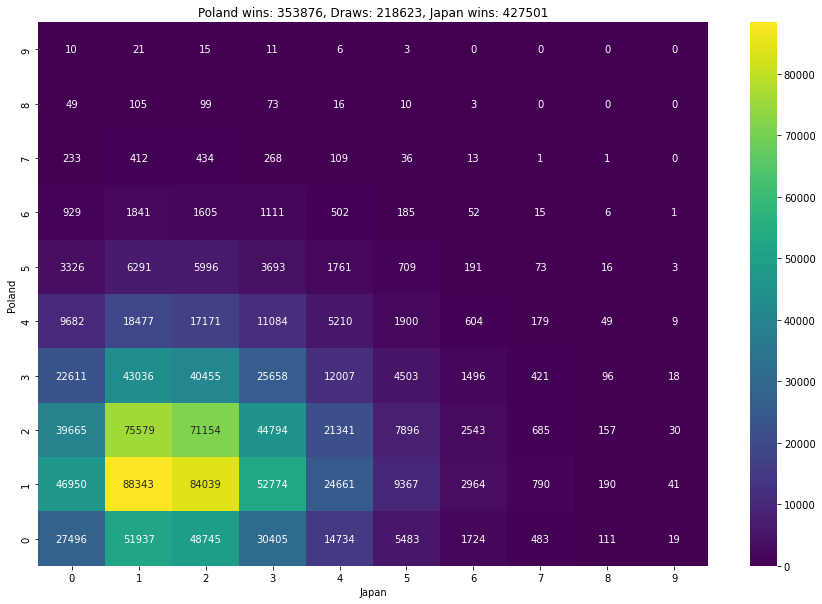

```python
simulateMatchHeatmap('Poland', 'Japan', 1000000)
```

## Everything is working well. We can see that the most probable score is 1-1 which occured 85k+ times. 2-1, 1-2, 2-2 are also highly probable.

# So now it's time to simulate the tournament!!!

# Simulation 1

## So firstly calculate xG for every team

```python
def calculate_xG_forAll(matches, teams, calculate_xG_fun):
  allTeams_xG = {}
  for country in teams:
    calculated_xG = calculate_xG(matches, country)
    if not math.isnan(calculated_xG):
      allTeams_xG[country] = calculated_xG
  return allTeams_xG
```

## Create a function that returns the winner and score in a match for a given teams. If the match can't result in a draw (knockout stage) we calculate the score once again

```python
allTeams_xG = calculate_xG_forAll(previous_matches, np.reshape(teams, [32]), calculate_xG)

def simulateMatch(teamA, teamB, canBeDraw=False):
  while True:
    scoreTeamA = simulateScore(allTeams_xG[teamA])
    scoreTeamB = simulateScore(allTeams_xG[teamB])
    if not canBeDraw:
      if scoreTeamA != scoreTeamB:
        break
    else:
      break

  if scoreTeamA > scoreTeamB: winner = teamA
  elif scoreTeamA == scoreTeamB: winner = 'Draw'
  else: winner = teamB

  return (scoreTeamA, scoreTeamB), winner
```

## Let's simulate one match and see what it comes up with

```python
simulateMatch('Poland', 'Japan', canBeDraw=True)
```

```
((0, 2), 'Japan')
```

## Create Groups

```python
def createGroups():
  groups = {}
  for i, groupName in enumerate(GROUP_NAMES):
    groups[groupName] = pd.DataFrame({'Country': teams[i],
                                          'Points': [0, 0, 0, 0],
                                          'Scored_goals': [0, 0, 0, 0],
                                          'Lost_goals': [0, 0, 0, 0],
                                          '+/-': [0, 0, 0, 0]})
  return groups
```

## Next, let's write function that simulates the whole tournament including group and knockout stages and returns the winner of the tournament

```python
def simulateTournament(sim_match_f):
  groups = createGroups()
  # Group Stage
  for groupName in GROUP_NAMES:
    for i in range(3):
      for j in range(i+1, 4):
        teamA = groups[groupName]['Country'][i]
        teamB = groups[groupName]['Country'][j]
        result, winner = sim_match_f(teamA, teamB, canBeDraw=True)

        groups[groupName].at[i, 'Scored_goals'] += result[0]
        groups[groupName].at[j, 'Scored_goals'] += result[1]
        groups[groupName].at[i, 'Lost_goals'] += result[1]
        groups[groupName].at[j, 'Lost_goals'] += result[0]
        if winner == teamA:
          groups[groupName].at[i, 'Points'] += 3
        elif winner == 'Draw':
          groups[groupName].at[i, 'Points'] += 1
          groups[groupName].at[j, 'Points'] += 1
        else:
          groups[groupName].at[j, 'Points'] += 3
    for i in range(4):
      groups[groupName].at[i, '+/-'] = groups[groupName]['Scored_goals'][i] - groups[groupName]['Lost_goals'][i]
    groups[groupName] = groups[groupName].sort_values(['Points', '+/-', 'Scored_goals'], ascending=False)
    groups[groupName].reset_index(drop=True, inplace=True)

  # Knockout Stage
  _, winner1eight1 = sim_match_f(groups['A']['Country'][0], groups['B']['Country'][1])
  _, winner1eight2 = sim_match_f(groups['C']['Country'][0], groups['D']['Country'][1])
  _, winner1eight3 = sim_match_f(groups['E']['Country'][0], groups['F']['Country'][1])
  _, winner1eight4 = sim_match_f(groups['G']['Country'][0], groups['H']['Country'][1])
  _, winner1eight5 = sim_match_f(groups['A']['Country'][1], groups['B']['Country'][0])
  _, winner1eight6 = sim_match_f(groups['C']['Country'][1], groups['D']['Country'][0])
  _, winner1eight7 = sim_match_f(groups['E']['Country'][1], groups['F']['Country'][0])
  _, winner1eight8 = sim_match_f(groups['G']['Country'][1], groups['H']['Country'][0])

  _, winnerQuarter1 = sim_match_f(winner1eight1, winner1eight2)
  _, winnerQuarter2 = sim_match_f(winner1eight3, winner1eight4)
  _, winnerQuarter3 = sim_match_f(winner1eight5, winner1eight6)
  _, winnerQuarter4 = sim_match_f(winner1eight7, winner1eight8)

  _, winnerSemiFinal1 = sim_match_f(winnerQuarter1, winnerQuarter2)
  _, winnerSemiFinal2 = sim_match_f(winnerQuarter3, winnerQuarter4)

  _, winnerFinal = sim_match_f(winnerSemiFinal1, winnerSemiFinal2)

  return winnerFinal
```

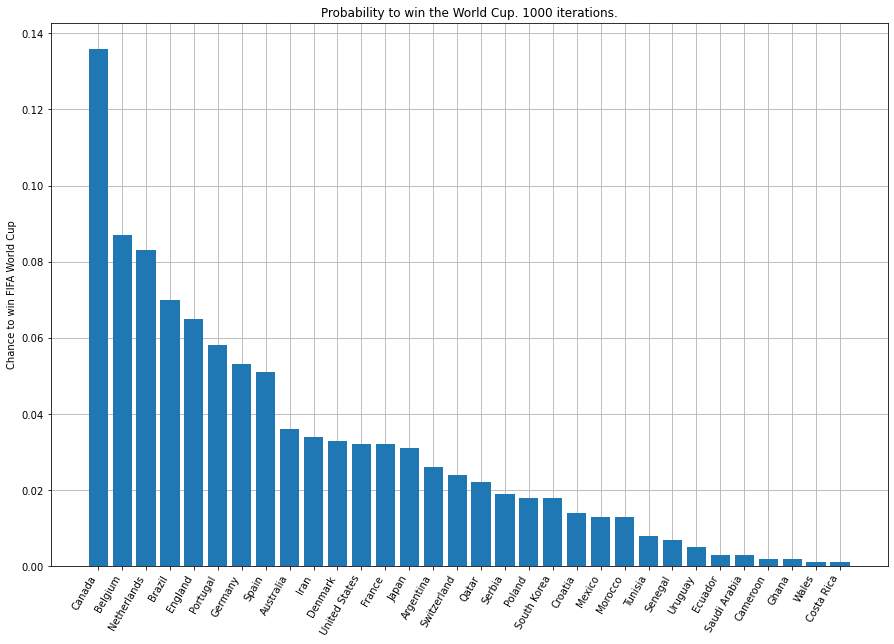

```python
winners = {}
for country in np.reshape(teams, [32]):
  winners[country] = 0

iterations = 1000
for _ in range(iterations):
  winner = simulateTournament(simulateMatch)
  winners[winner] += 1

winners = dict(sorted(winners.items(), key=lambda x: x[1], reverse=True))

for key in winners.keys():
  winners[key] /= iterations
plt.figure(figsize=(15, 10))
plt.grid(zorder=0)
plt.xticks(rotation=60, ha='right')
plt.grid
plt.ylabel('Chance to win FIFA World Cup')
plt.title(f'Probability to win the World Cup. {iterations} iterations.')
plt.bar(winners.keys(), winners.values(), zorder=3);
```

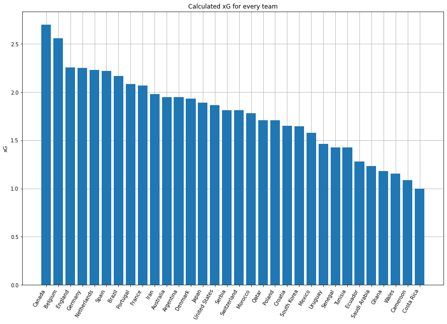

```python
temp_allTeams_xG = dict(sorted(allTeams_xG.items(), key=lambda x: x[1], reverse=True))
plt.figure(figsize=(15, 10))
plt.grid(zorder=0)
plt.xticks(rotation=60, ha='right')
plt.grid
plt.ylabel('xG')
plt.title('Calculated xG for every team')
plt.bar(temp_allTeams_xG.keys(), temp_allTeams_xG.values(), zorder=3);
```

## We can see high correlation between xG for a team and its chance to win the tournament. So maybe our assumptions were bad..

## In the previous simulations we used xG of each team calculated just by averaging scored goals in the previous matches - most importantly, we haven't consider who our team were playing against.

## Let's see 15 of the Canada's latest matches and compare them to matches with e.g. Spain

Canada's last 15 matches:

```python
previous_matches[(previous_matches['home_team'] == 'Canada') | (previous_matches['away_team'] == 'Canada')][-15:]
```

|  | date | home_team | away_team | home_score | away_score |
| --- | --- | --- | --- | --- | --- |
| 1148 | 2021-10-13 | Canada | Panama | 4.0 | 1.0 |
| 1168 | 2021-11-12 | Canada | Costa Rica | 1.0 | 0.0 |
| 1201 | 2021-11-16 | Canada | Mexico | 2.0 | 1.0 |
| 1253 | 2022-01-27 | Honduras | Canada | 0.0 | 2.0 |
| 1267 | 2022-01-30 | Canada | United States | 2.0 | 0.0 |
| 1280 | 2022-02-02 | El Salvador | Canada | 0.0 | 2.0 |
| 1286 | 2022-03-24 | Costa Rica | Canada | 1.0 | 0.0 |
| 1312 | 2022-03-27 | Canada | Jamaica | 4.0 | 0.0 |
| 1341 | 2022-03-30 | Panama | Canada | 1.0 | 0.0 |
| 1385 | 2022-06-09 | Canada | Curaçao | 4.0 | 0.0 |
| 1409 | 2022-06-13 | Honduras | Canada | 2.0 | 1.0 |
| 1433 | 2022-09-23 | Canada | Qatar | 2.0 | 0.0 |
| 1453 | 2022-09-27 | Canada | Uruguay | 0.0 | 2.0 |
| 1479 | 2022-11-11 | Bahrain | Canada | 2.0 | 2.0 |
| 1488 | 2022-11-17 | Japan | Canada | 1.0 | 2.0 |

Spain last 15 matches:

```python
previous_matches[(previous_matches['home_team'] == 'Spain') | (previous_matches['away_team'] == 'Spain')][-15:]
```

|  | date | home_team | away_team | home_score | away_score |
| --- | --- | --- | --- | --- | --- |
| 1050 | 2021-09-05 | Spain | Georgia | 4.0 | 0.0 |
| 1077 | 2021-09-08 | Kosovo | Spain | 0.0 | 2.0 |
| 1091 | 2021-10-06 | Italy | Spain | 1.0 | 2.0 |
| 1128 | 2021-10-10 | Spain | France | 1.0 | 2.0 |
| 1162 | 2021-11-11 | Greece | Spain | 0.0 | 1.0 |
| 1185 | 2021-11-14 | Spain | Sweden | 1.0 | 0.0 |
| 1310 | 2022-03-26 | Spain | Albania | 2.0 | 1.0 |
| 1336 | 2022-03-29 | Spain | Iceland | 5.0 | 0.0 |
| 1352 | 2022-06-02 | Spain | Portugal | 1.0 | 1.0 |
| 1369 | 2022-06-05 | Czech Republic | Spain | 2.0 | 2.0 |
| 1387 | 2022-06-09 | Switzerland | Spain | 0.0 | 1.0 |
| 1403 | 2022-06-12 | Spain | Czech Republic | 2.0 | 0.0 |
| 1443 | 2022-09-24 | Spain | Switzerland | 1.0 | 2.0 |
| 1463 | 2022-09-27 | Portugal | Spain | 0.0 | 1.0 |
| 1489 | 2022-11-17 | Jordan | Spain | 1.0 | 3.0 |

## There is no doubt that Canada has played against much worse opponents (Jamaica, El Salvador, Curaçao, etc.) than Spain (Portugal, Sweden, Switzerland, France, Italy)

## To solve this problem that we encountered we need one more metric and it is ELO Football Ranking. Based on this, we can take into account rank of the opponent in the previous matches to calculate correct xG for future matches. Let's do that..

# Simulation 2

```python
ratings = pd.read_csv('EloRatings.csv', index_col=0, squeeze=True).to_dict()
ratings['Nepal'], ratings['Latvia'], ratings['France'], ratings['Netherlands']
```

```
(933, 1352, 1993, 2047)
```

## Firstly let's import all matches once again

```python
relevantTeams = ratings.keys()

allMatches = pd.read_csv('results.csv')
allMatches = allMatches[allMatches['date'] < END_DATE]
allMatches = allMatches[(allMatches['home_team'].isin(relevantTeams)) & (allMatches['away_team'].isin(relevantTeams))]
allMatches = allMatches.drop(['tournament', 'city', 'country', 'neutral'], axis=1)
allMatches.reset_index(drop=True, inplace=True)
allMatches.tail()
```

|  | date | home_team | away_team | home_score | away_score |
| --- | --- | --- | --- | --- | --- |
| 41461 | 2022-11-19 | Sweden | Algeria | 2.0 | 0.0 |
| 41462 | 2022-11-19 | Turkey | Czech Republic | 2.0 | 1.0 |
| 41463 | 2022-11-19 | United Arab Emirates | Kazakhstan | 2.0 | 1.0 |
| 41464 | 2022-11-19 | Estonia | Lithuania | 2.0 | 0.0 |
| 41465 | 2022-11-19 | Latvia | Iceland | 1.0 | 1.0 |

## And calculate xG for every team that is available in the ELO ranking

```python
all_xG = calculate_xG_forAll(allMatches, relevantTeams, calculate_xG)
all_xG['Nepal'], all_xG['Latvia']
```

```
(0.7539267015706806, 1.2287735849056605)
```

## Then, let's see if there is a correlation between the team's xGs and the team's rating in a single match.

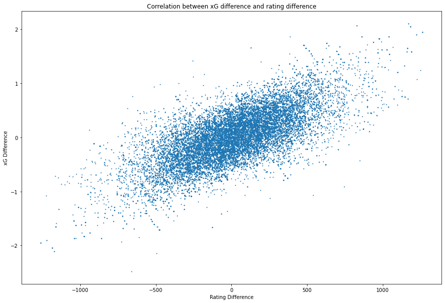

```python
ratingDifferences = []
xG_differences = []
for i in allMatches.index:
  homeTeam = allMatches['home_team'][i]
  awayTeam = allMatches['away_team'][i]
  homeTeamScore = allMatches['home_score'][i]
  awayTeamScore = allMatches['away_score'][i]

  ratingDifferences.append(ratings[homeTeam] - ratings[awayTeam])
  xG_differences.append(all_xG[homeTeam] - all_xG[awayTeam])
plt.figure(figsize=(15, 10))
plt.xlabel('Rating Difference')
plt.ylabel('xG Difference')
plt.title('Correlation between xG difference and rating difference')
plt.scatter(ratingDifferences, xG_differences, s = 1);
```

## As we can see, there is a straight line that describes that dependency. Of course data is a bit noisy, but we consider most of the outliers to be matches played many many years ago (dataset contains matches from 1872), so the rating of teams could be totally different then.

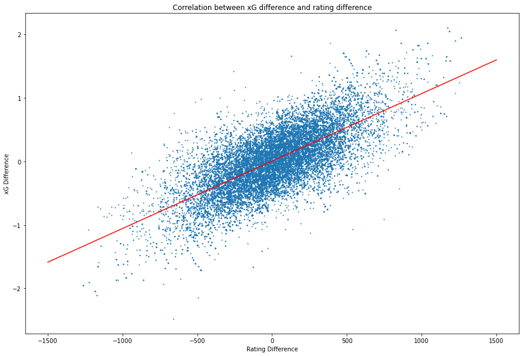

```python
from sklearn.linear_model import LinearRegression
reg = LinearRegression().fit(np.reshape(ratingDifferences, [41466, 1]), xG_differences)
X = [[-1500], [1500]]
y = reg.predict(X)
plt.figure(figsize=(15, 10))
plt.xlabel('Rating Difference')
plt.ylabel('xG Difference')
plt.title('Correlation between xG difference and rating difference')
plt.scatter(ratingDifferences, xG_differences, s = 1)
plt.plot(X, y, c='r');
```

## So now, we should simulate the result in the match based on the xG but the xG must be scaled basing on the rating difference to replicate what the previous graph shows us

```python
def simulateMatch_v2(teamA, teamB, canBeDraw=False):
  ratingDifference = ratings[teamA]- ratings[teamB]
  xG_difference = reg.predict([[ratingDifference]])[0]
  while True:
    scoreTeamA = simulateScore(allTeams_xG[teamA] + xG_difference/2)
    scoreTeamB = simulateScore(allTeams_xG[teamB] - xG_difference/2)
    if not canBeDraw:
      if scoreTeamA != scoreTeamB:
        break
    else:
      break

  if scoreTeamA > scoreTeamB: winner = teamA
  elif scoreTeamA == scoreTeamB: winner = 'Draw'
  else: winner = teamB

  return (scoreTeamA, scoreTeamB), winner
```

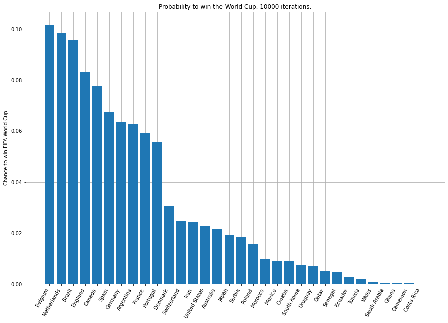

```python
winners = {}
for country in np.reshape(teams, [32]):
  winners[country] = 0

iterations = 10000
for _ in range(iterations):
  winner = simulateTournament(simulateMatch_v2)
  winners[winner] += 1

winners = dict(sorted(winners.items(), key=lambda x: x[1], reverse=True))

for key in winners.keys():
  winners[key] /= iterations
plt.figure(figsize=(15, 10))
plt.grid(zorder=0)
plt.xticks(rotation=60, ha='right')
plt.grid
plt.ylabel('Chance to win FIFA World Cup')
plt.title(f'Probability to win the World Cup. {iterations} iterations.')
plt.bar(winners.keys(), winners.values(), zorder=3);
```

## We can still observe some unexpected results like Canada still being too high in the ranking. One thing we've forgotten is to take the recent games into account more than the ones that took place few years ago.

# Simulation 3

## To do that we need to modify the calculate xG function

```python
from datetime import date
def calculate_xG_v2(matches, team):
  matches['start_date'] = pd.to_datetime([START_DATE for i in range(len(matches))])
  matches['diff_years'] = (matches['date'] - matches['start_date']) / np.timedelta64(1, 'Y')
  home = matches[matches['home_team'] == team]
  away = matches[matches['away_team'] == team]

  goals = np.array(home['home_score'].tolist() + away['away_score'].tolist())
  dates = np.array(home['diff_years'].tolist() + away['diff_years'].tolist())

  return sum(goals*dates)/sum(dates)

calculate_xG_v2(previous_matches, 'Cameroon')
```

```
1.221675537862862
```

## Now we need to replace a xG dictionary with new xG values

```python
allTeams_xG_new = calculate_xG_forAll(previous_matches, np.reshape(teams, [32]), calculate_xG_v2)
```

```python
def simulateMatch_v3(teamA, teamB, canBeDraw=False):
  ratingDifference = ratings[teamA]- ratings[teamB]
  xG_difference = reg.predict([[ratingDifference]])[0]
  while True:
    scoreTeamA = simulateScore(allTeams_xG_new[teamA] + xG_difference)
    scoreTeamB = simulateScore(allTeams_xG_new[teamB] - xG_difference)
    if not canBeDraw:
      if scoreTeamA != scoreTeamB:
        break
    else:
      break

  if scoreTeamA > scoreTeamB: winner = teamA
  elif scoreTeamA == scoreTeamB: winner = 'Draw'
  else: winner = teamB

  return (scoreTeamA, scoreTeamB), winner
```

## Time for simulation

```
<BarContainer object of 32 artists>
```

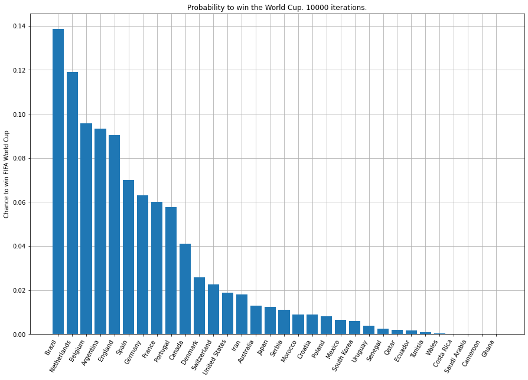

```python
winners = {}
for country in np.reshape(teams, [32]):
  winners[country] = 0

iterations = 10000
for _ in range(iterations):
  winner = simulateTournament(simulateMatch_v3)
  winners[winner] += 1

winners = dict(sorted(winners.items(), key=lambda x: x[1], reverse=True))

for key in winners.keys():
  winners[key] /= iterations
plt.figure(figsize=(15, 10))
plt.grid(zorder=0)
plt.xticks(rotation=60, ha='right')
plt.grid
plt.ylabel('Chance to win FIFA World Cup')
plt.title(f'Probability to win the World Cup. {iterations} iterations.')
plt.bar(winners.keys(), winners.values(), zorder=3)
```

## Canada still stays really high in the overall ranking which is suspicious. Probably we have forgotten something. What about last matches? We are considering rating only in future matches and what about the last matches?